# Bag of Words

From text to numbers

Luis Sattelmayer

2026-01-20

## Converting text to numbers

- Text as data consists in transforming text into numbers
- Different ways to do this
- Start with *Bag of Words* representation

## Bag of Words (BoW)

> Bag of words featurization quantifies the frequency of words in text documents for processing in machine learning models
- An unstructured assortment of all words present in a text
- Rely on word frequency counts

## Bag of Words

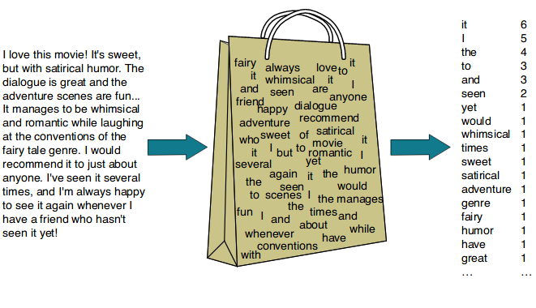

## Limits of BoW

- **Word correlation**:
  - context blind
  - election and president co-ocurr more often than president and poet
  - a simple individual term frequency omits this relationship
- **Compound words**:
  - without accounting for words that belong together, every word will be judged individually
  - “White House” treated as equal to “white” + “house”/“Donald Trump” will be treated as “donald” + “trump”
  - solution: n_grams

## Limits of BoW

- **Polysemous words**:
  - multiple meanings: climate (global warming) $\neq$ climate (tense, climate of a debate)
  - CON-tent $\neq$ con-TENT
- **Sparsity**:
  - each word is a feature or dimension of the model
  - inefficient for computing

## Limits of BoW

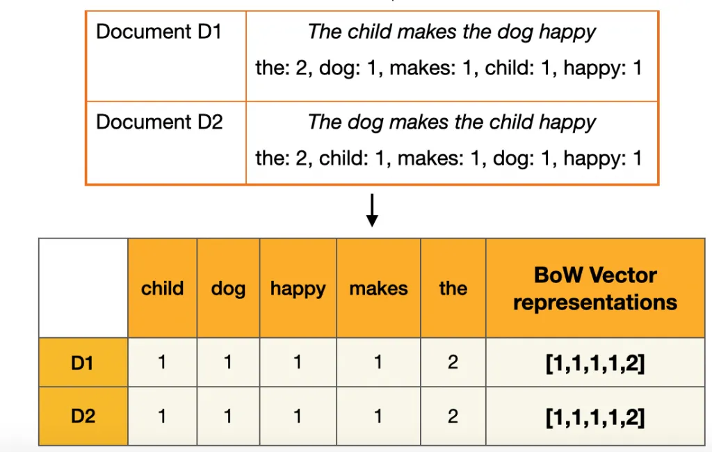

## Solutions for the Limitations

- **Bag of n-grams**:
  - minimum a bi-gram: “New York”, “Eiffel Tower”, “Donald Trump”, “White House”
  - still not 100% informative: “on the”, “will be”
- **Normalization*/*Preprocessing** (see later slides):
  - stemming
  - removing punctuation
  - removing stopwords

## N-grams

| **n-gram Size** | **Description** | **n-gram Examples** |
| --- | --- | --- |
| **Unigram (1-gram)** | Single word | “Natural,” “language,” “processing” |
| **Bigram (2-gram)** | Sequence of two consecutive words | “Natural language,” “language processing” |
| **Trigram (3-gram)** | Sequence of three consecutive words | “Natural language processing” |
| **4-gram** | Sequence of four consecutive words | “Natural language processing tasks” |

## Zipf’s Law

> When we rank observations by their frequency, the frequency of a specific observation occurrring is inversely proportional to its rank.
- The most common words in a language appear twice as often as the next common one
- *the* appears 7% of the time in the Brown Corpus of American English, while *of* accounts for 3.5%
- This means: the most common, are the least informative words

## Zipf’s Law

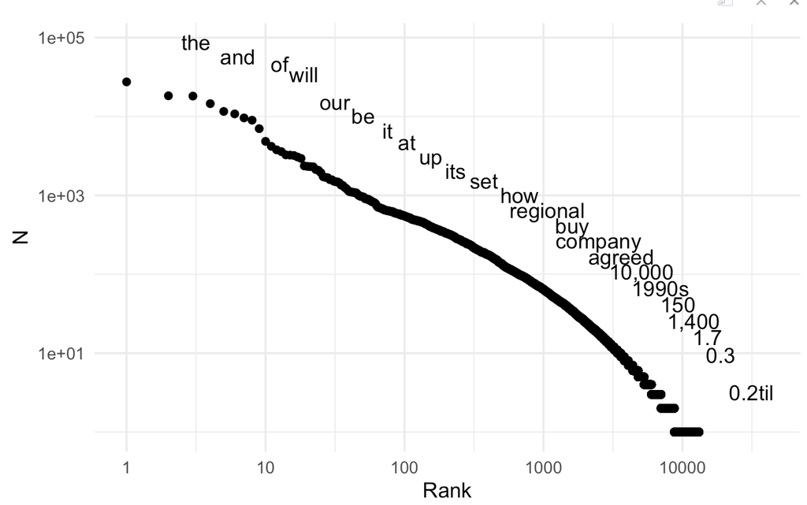

## Preprocessing/Normalizing

- **Tokenization**
  - splitting text in smaller units of analysis
  - eg.: sentences, quasi-sentences, words can each be tokens
- **Lowercasing**
  - “Cat” and “cat” are not the same for Bag of Words
- **Removing Stopwords**
  - common words that carry little semantic meaning: “is”, “of”, “the,” “and”
  - focuses on meaningful words and reduces the dimensionality of the BoW representation
- **Removing Punctuation**
  - stripping commas, dots and so on
- **Stemming**
  - Reducing words to their root or base form by removing suffixes: “running” –> “run”

## Stemming vs Lemmatizing

[output not shown]

## Term-Document Matrix

> A matrix where rows represent terms (e.g., words, phrases, or n-grams) and columns represent documents.
- Each cell contains a value representing the occurrence or importance of the term in the corresponding document
- **Common Values in Cells**:
  - *Raw Term Frequency* (TF): Counts how often a term appears in a document
  - *Binary Presence*: 1 if the term appears in the document, otherwise 0
  - *Weighted Measures*: TF-IDF (Term Frequency-Inverse Document Frequency)
- Sparse matrix, inefficient for large corpora

## Document-Term Matrix

> A matrix where rows represent documents and columns represent terms (e.g., words, phrases, or n-grams)
- Each cell contains a value that represents the occurrence or importance of the term in the document
- Can be used for same purposes as TDF
- Very sparse, when large vocabulary size

**Here is a TDM**

| **Term** | **Doc1** | **Doc2** | **Doc3** |
| --- | --- | --- | --- |
| climate | 5 | 2 | 0 |
| president | 3 | 0 | 1 |
| immigration | 2 | 4 | 6 |
| economy | 1 | 1 | 3 |

**Here is a DTM**

| **Document** | **climate** | **president** | **immigration** | **economy** |
| --- | --- | --- | --- | --- |
| Doc1 | 5 | 3 | 2 | 1 |
| Doc2 | 2 | 0 | 4 | 1 |
| Doc3 | 0 | 1 | 6 | 3 |

## TDM vs. DTM

[output not shown]

## tf-idf

- In standard bag of words models, semantically irrelevant words have the highest term frequency, and so greatest weight in a model
- **Term frequency-inverse document frequency** can correct this
- TF-IDF accounts for the word’s prevalence throughout every document in a text set

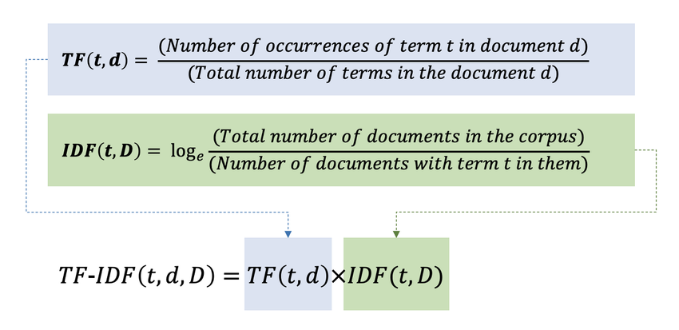

## tf-idf

- *High tf-idf*: frequent term in the document but rare in the overall corpus –> more unique or important for that document
- *Low tf-idf*: term is either frequent across the corpus (e.g., stopwords like “the,” “and”) or infrequent in the document, meaning it has less distinguishing power
- Input for machine learning models:
  - text classification (e.g., spam detection, sentiment analysis, random forests)
  - document clustering
- Information Retrieval:
  - search engines
  - document matching (using cosine similarity –> Thursday)
- Anomaly Detection

## Use cases of BoW

1. Scaling
2. Topic Modeling
3. Text classification

## Scaling

> Quantify and compare the positions of documents (e.g., texts, articles, speeches) along one or more dimensions based on their linguistic content
- Use cases in Political Science: Map political speeches or manifestos along ideological dimensions (e.g., left-right, liberal-conservative)
  - Wordscores (Benoit and Laver 2003) or Wordfish

## Scaling application

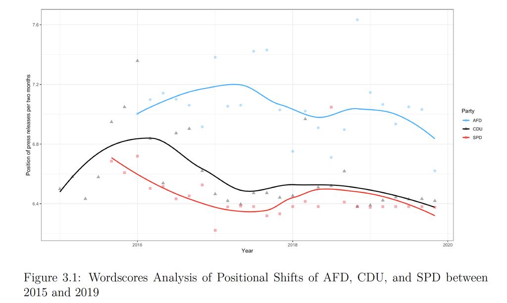

An uninformed scaling application by myself a couple of years ago

## Summary: Bag of Words

- **Definition**: Represents text as an unordered collection of words, ignoring grammar and word order
  - focuses on **word frequency**.
  - treats documents as a “bag” of individual terms
- **Strengths**:
  - Simple and intuitive for feature extraction
  - Effective for basic text analysis tasks like classification and clustering
- **Limitations**: context blind, sparse representation, polysemy, compound words
  - apply **preprocessing**: tokenization, stopword removal, stemming, lemmatization
- **Applications**:
  - **n-grams**, **TF-IDF**,Scaling documents along dimensions (e.g., ideology), Topic modeling and clustering

## References

Benoit, Kenneth, and Michael Laver. 2003. “Estimating Irish Party Policy Positions Using Computer Wordscoring: The 2002 Election–a Research Note.” *Irish Political Studies* 18 (1): 97–107.